# Statistical Analysis: Valence Processing

2026-01-13

# Preparation

In this section, we load the packages required for the subsequent analyses.

```r
# Data manipulation
library(tidyverse)
library(tidyr)
library(dplyr)

# Descriptive statistics
library(psych)

# Visualization
library(ggplot2)
library(corrplot)

# MIxed models
library(lme4)
library(lmerTest)

# Estimated marginal means
library (emmeans)
```

# Participant Information

Before analysing the experimental data, we examine whether participants’ self-assessed English proficiency correlates with their LexTALE scores. LexTALE is used as an objective measure of English vocabulary knowledge, while the self-assessment scores reflect participants’ perceived language abilities in four domains:

- speaking
- listening
- reading
- writing

## Correlation between LexTALE and Self-Assessment

The following data frame contains the LexTALE results and the self-assessment scores for each participant.

```r
# Dataframe of all self-assessment scores for each participant
participant_df <- data.frame(
  lex_tale_result = c(65,67.5,65,81.25,87.5,55,72.5,92.5,67.5,82.5,95,56.25,76.25,78.75,57.5,91.25),
  Speaking  = c(4,7,5,6,5,5,6,7,4,6,8,4,6,5,5,5),
  Listening = c(7,7,6,7,8,7,6,6,4,6,8,3,6,6,5,6),
  Reading   = c(5,7,7,6,8,6,6,5,5,7,8,3,6,7,5,7),
  Writing  = c(4,5,3,7,6,4,6,5,4,6,7,3,6,5,5,6)
)

# Correlations of each domain with LexTALE
cor(participant_df$lex_tale_result, participant_df$Speaking)
```

```
## [1] 0.582753
```

```r
cor(participant_df$lex_tale_result, participant_df$Listening)
```

```
## [1] 0.4768127
```

```r
cor(participant_df$lex_tale_result, participant_df$Reading)
```

```
## [1] 0.5780826
```

```r
cor(participant_df$lex_tale_result, participant_df$Writing)
```

```
## [1] 0.7375067
```

```r
# Significance tests of the correlations
cor.test(participant_df$lex_tale_result, participant_df$Speaking)
```

```
##
##  Pearson's product-moment correlation
##
## data:  participant_df$lex_tale_result and participant_df$Speaking
## t = 2.6832, df = 14, p-value = 0.01784
## alternative hypothesis: true correlation is not equal to 0
## 95 percent confidence interval:
##  0.1224082 0.8367447
## sample estimates:
##      cor
## 0.582753
```

```r
cor.test(participant_df$lex_tale_result, participant_df$Listening)
```

```
##
##  Pearson's product-moment correlation
##
## data:  participant_df$lex_tale_result and participant_df$Listening
## t = 2.0296, df = 14, p-value = 0.06185
## alternative hypothesis: true correlation is not equal to 0
## 95 percent confidence interval:
##  -0.02474025  0.78659865
## sample estimates:
##       cor
## 0.4768127
```

```r
cor.test(participant_df$lex_tale_result, participant_df$Reading)
```

```
##
##  Pearson's product-moment correlation
##
## data:  participant_df$lex_tale_result and participant_df$Reading
## t = 2.6508, df = 14, p-value = 0.019
## alternative hypothesis: true correlation is not equal to 0
## 95 percent confidence interval:
##  0.1154647 0.8346203
## sample estimates:
##       cor
## 0.5780826
```

```r
cor.test(participant_df$lex_tale_result, participant_df$Writing)
```

```
##
##  Pearson's product-moment correlation
##
## data:  participant_df$lex_tale_result and participant_df$Writing
## t = 4.0861, df = 14, p-value = 0.001112
## alternative hypothesis: true correlation is not equal to 0
## 95 percent confidence interval:
##  0.3811413 0.9030643
## sample estimates:
##       cor
## 0.7375067
```

```r
# Matrix for nicer viewing
cor_matrix <- cor(participant_df)
cor_matrix
```

```
##                 lex_tale_result  Speaking Listening   Reading   Writing
## lex_tale_result       1.0000000 0.5827530 0.4768127 0.5780826 0.7375067
## Speaking              0.5827530 1.0000000 0.5287832 0.4847179 0.6423641
## Listening             0.4768127 0.5287832 1.0000000 0.7669903 0.5560096
## Reading               0.5780826 0.4847179 0.7669903 1.0000000 0.5560096
## Writing               0.7375067 0.6423641 0.5560096 0.5560096 1.0000000
```

## Visualization of the Correlations

To visualise the relationship between LexTALE scores and self-assessed language skills, the data are transformed into long format and plotted separately for each skill.

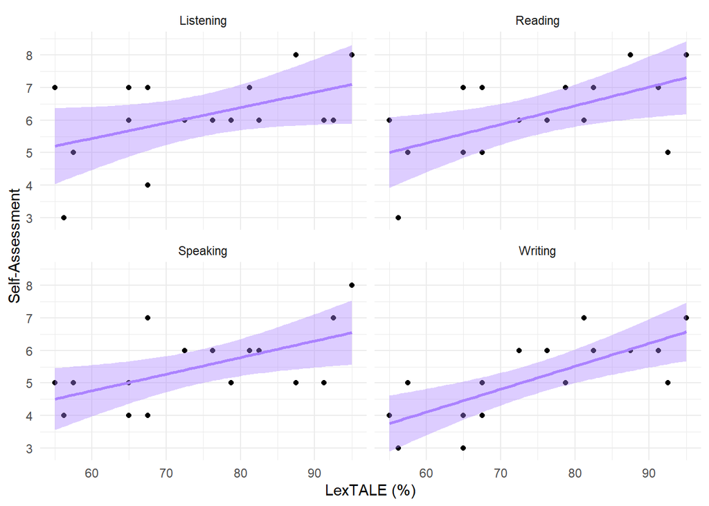

```r
# Transform dataframe to long format
corr_df <- participant_df %>%
  pivot_longer(
    cols = Speaking:Writing,
    names_to = "skill",
    values_to = "score"
  )

# Plot
p <- ggplot(corr_df,
       aes(x = lex_tale_result, y = score)) +
  geom_point() +
  geom_smooth(method = "lm", se = TRUE, color = "mediumpurple1", fill = "mediumpurple1") +
  facet_wrap(~skill) +
  theme_minimal() +
  labs(x = "LexTALE (%)", y = "Self-Assessment")

p
```

```r
# Save
ggsave(
  "lextale_correlations.png",
  plot = p,
  width = 8,
  height = 6
)
```

# Experimental Data

## Loading the Dataset

The experimental dataset containing reaction times and accuracy values is loaded from a CSV file.

```r
descr_df <- read_csv("LDT_longlist_2026_01_09.csv", show_col_types = FALSE)
```

## Descriptive Statistics

Two main measures are analysed:

- **Accuracy** (whether the response was correct)
- **Reaction time (RT)** in milliseconds

### Initial Inspection of the Data

Before conducting statistical analyses, the dataset is filtered to include only experimental trials containing real words. This removes practice items and nonword trials.

```r
# Remove all practice items, remove all nonword trials
pre_filtered_df <- subset(descr_df, Item_type == "exp" & Condition == "word")
pre_filtered_df
```

```
## # A tibble: 1,530 × 10
##    Accuracy Condition Emotional_valence_cat Emotional_valence_cont Item_type
##       <dbl> <chr>     <chr>                 <chr>                  <chr>
##  1        1 word      negative              2.74                   exp
##  2        1 word      negative              2.18                   exp
##  3        1 word      negative              1.9                    exp
##  4        1 word      positive              7.24                   exp
##  5        1 word      neutral               5.02                   exp
##  6        1 word      neutral               5.5                    exp
##  7        1 word      neutral               5.18                   exp
##  8        1 word      neutral               5.48                   exp
##  9        1 word      positive              7.11                   exp
## 10        1 word      neutral               4.81                   exp
## # ℹ 1,520 more rows
## # ℹ 5 more variables: Length <dbl>, Lg10SUBTLEX_US <chr>, Participant <dbl>,
## #   RT <dbl>, Stimulus <chr>
```